# EDA

## Set up the enviroment

```r
url <- "https://github.com/DavidVarga1995/understat_data/archive/refs/heads/main.zip"
dest <- "./understat_data.zip"

download.file(url, dest)
unzip(dest)
```

```r
library(dplyr)
```

Read the data

```r
epl_shots <- read.csv('./understat_data-main/data/Shots/EPL_shots_2020.csv')
epl_players <- read.csv('./understat_data-main/data/Players/EPL_players_2020.csv')
epl_games <- read.csv('./understat_data-main/data/Games/EPL_games_2020.csv')
epl_fixtures <- read.csv('./understat_data-main/data/Fixtures/EPL_fixtures_2020.csv')
bundesliga_shots <- read.csv('./understat_data-main/data/Bundesliga_2019/Bundesliga_shots_2019.csv')
```

Descriptive Statistics

```r
bundesliga_shots_attributes <- select(bundesliga_shots, 'minute', 'h_goals', 'a_goals', 'situation', 'lastAction', 'X', 'Y', 'shotType', 'xG', 'result')

print(summary(bundesliga_shots_attributes))
```

```
##      minute         h_goals         a_goals       situation
##  Min.   : 0.00   Min.   :0.000   Min.   :0.000   Length:8148
##  1st Qu.:27.00   1st Qu.:1.000   1st Qu.:1.000   Class :character
##  Median :49.00   Median :1.000   Median :1.000   Mode  :character
##  Mean   :48.92   Mean   :1.696   Mean   :1.582
##  3rd Qu.:72.00   3rd Qu.:2.000   3rd Qu.:2.000
##  Max.   :97.00   Max.   :8.000   Max.   :6.000
##   lastAction              X                Y            shotType
##  Length:8148        Min.   :0.0040   Min.   :0.0500   Length:8148
##  Class :character   1st Qu.:0.7870   1st Qu.:0.4180   Class :character
##  Mode  :character   Median :0.8680   Median :0.5000   Mode  :character
##                     Mean   :0.8488   Mean   :0.5028
##                     3rd Qu.:0.9130   3rd Qu.:0.5880
##                     Max.   :0.9950   Max.   :0.9750
##        xG             result
##  Min.   :0.00000   Length:8148
##  1st Qu.:0.02584   Class :character
##  Median :0.05354   Mode  :character
##  Mean   :0.11916
##  3rd Qu.:0.10300
##  Max.   :0.97515
```

Summarize factors

```r
table(bundesliga_shots_attributes$situation)
```

```
##
## DirectFreekick     FromCorner       OpenPlay        Penalty       SetPiece
##            299           1316           5893             73            567
```

As we can see the most common situation of a shot is open play. The second most common situation of a shot is corner.

The frequency of set pieces and direct freekicks is significant, too.

However the frequency of penalties as a situation of a shot is insignificant.

```r
table(bundesliga_shots_attributes$lastAction)
```

```
##
##         Aerial   BallRecovery      BallTouch    BlockedPass           Card
##            735            175            202              7              4
##      Challenge        Chipped      Clearance  CornerAwarded          Cross
##              5            381              4              8           1192
##   Dispossessed            End           Foul           Goal       HeadPass
##             38              4             16              7            198
##   Interception         LayOff           None    OffsidePass           Pass
##              6             44            973              2           2805
##          Punch        Rebound           Save       Standard          Start
##              1            367              2            372              1
## SubstitutionOn         Tackle         TakeOn    Throughball
##              2             11            450            136
```

Obviously the most common action before a shot is a pass. However the frequency of crosses and aerials is significant, too.

The frequency of standard situations (set pieces), chipped balls, take-ons, rebounds, ball recoveries, head passes, through balls and ball touches is also notable.

The frequency of the remaining values is insignificant.

```r
table(bundesliga_shots_attributes$shotType)
```

```
##
##          Head      LeftFoot OtherBodyPart     RightFoot
##          1499          2437            34          4178
```

As expected the majority of shots is shot by right or left foot. However the frequency of headers is significant, too.

The remaning shots are shot with other body part.

```r
table(bundesliga_shots_attributes$result)
```

```
##
## BlockedShot        Goal MissedShots     OwnGoal   SavedShot  ShotOnPost
##        2016         954        3132          28        1897         121
```

The result of the shot most frequently is a miss or a blocked shot. However the the amount of saved shots is almost equal with the amount of saved shots.

If a shot is not missed, blocked or saved by the goalkeeper it can be a goal or it can hit the post.

The amount of own goals is insignificant.

```r
table(bundesliga_shots_attributes$result, bundesliga_shots_attributes$shotType)
```

```
##
##               Head LeftFoot OtherBodyPart RightFoot
##   BlockedShot  187      687             2      1140
##   Goal         168      284             2       500
##   MissedShots  822      865            17      1428
##   OwnGoal        4       12             5         7
##   SavedShot    299      547             7      1044
##   ShotOnPost    19       42             1        59
```

```r
table(bundesliga_shots_attributes$lastAction, bundesliga_shots_attributes$shotType)
```

```
##
##                  Head LeftFoot OtherBodyPart RightFoot
##   Aerial          561       64            13        97
##   BallRecovery      0       65             0       110
##   BallTouch         5       64             1       132
##   BlockedPass       0        3             0         4
##   Card              0        1             2         1
##   Challenge         1        1             0         3
##   Chipped          75      108             0       198
##   Clearance         1        1             1         1
##   CornerAwarded     3        1             0         4
##   Cross           726      160            14       292
##   Dispossessed      1       12             1        24
##   End               0        2             0         2
##   Foul              7        2             0         7
##   Goal              3        3             0         1
##   HeadPass         31       55             0       112
##   Interception      0        2             0         4
##   LayOff            0       13             0        31
##   None             50      362             2       559
##   OffsidePass       0        0             0         2
##   Pass             11     1002             0      1792
##   Punch             1        0             0         0
##   Rebound          21      130             0       216
##   Save              0        2             0         0
##   Standard          0      147             0       225
##   Start             0        0             0         1
##   SubstitutionOn    1        0             0         1
##   Tackle            0        7             0         4
##   TakeOn            0      183             0       267
##   Throughball       1       47             0        88
```

```r
table(bundesliga_shots_attributes$situation, bundesliga_shots_attributes$shotType)
```

```
##
##                  Head LeftFoot OtherBodyPart RightFoot
##   DirectFreekick    0      131             0       168
##   FromCorner      646      264            11       395
##   OpenPlay        583     1925            16      3369
##   Penalty           0       16             0        57
##   SetPiece        270      101             7       189
```

```r
table(bundesliga_shots_attributes$lastAction, bundesliga_shots_attributes$result)
```

```
##
##                  BlockedShot Goal MissedShots OwnGoal SavedShot ShotOnPost
##   Aerial                 140   50         418       0       121          6
##   BallRecovery            40   12          64       0        57          2
##   BallTouch               60   13          84       1        39          5
##   BlockedPass              3    0           0       0         4          0
##   Card                     0    0           2       2         0          0
##   Challenge                1    0           0       3         1          0
##   Chipped                 65   38         162       0       113          3
##   Clearance                0    0           0       4         0          0
##   CornerAwarded            4    0           2       0         2          0
##   Cross                  176  166         610       0       222         18
##   Dispossessed            16    4           5       2        10          1
##   End                      1    0           1       0         2          0
##   Foul                     7    2           3       3         1          0
##   Goal                     4    1           0       0         2          0
##   HeadPass                38   27          90       0        38          5
##   Interception             3    0           2       0         1          0
##   LayOff                  20    2          11       0        11          0
##   None                   306   74         402       9       170         12
##   OffsidePass              1    0           0       0         1          0
##   Pass                   804  289         924       0       742         46
##   Punch                    0    0           0       1         0          0
##   Rebound                 92   79         121       0        69          6
##   Save                     0    0           0       2         0          0
##   Standard                89   77          93       0       106          7
##   Start                    0    0           0       0         1          0
##   SubstitutionOn           1    1           0       0         0          0
##   Tackle                   3    0           4       0         4          0
##   TakeOn                 132   66         114       1       131          6
##   Throughball             10   53          20       0        49          4
```

```r
table(bundesliga_shots_attributes$situation, bundesliga_shots_attributes$result)
```

```
##
##                  BlockedShot Goal MissedShots OwnGoal SavedShot ShotOnPost
##   DirectFreekick          89   18          93       0        93          6
##   FromCorner             353  116         652       3       176         16
##   OpenPlay              1467  701        2119      22      1494         90
##   Penalty                  0   59           0       0        13          1
##   SetPiece               107   60         268       3       121          8
```

```r
table(bundesliga_shots_attributes$lastAction, bundesliga_shots_attributes$situation)
```

```
##
##                  DirectFreekick FromCorner OpenPlay Penalty SetPiece
##   Aerial                      0        340      267       0      128
##   BallRecovery                0          0      175       0        0
##   BallTouch                   0         33      157       0       12
##   BlockedPass                 0          1        6       0        0
##   Card                        0          0        3       0        1
##   Challenge                   0          1        4       0        0
##   Chipped                     0         19      324       0       38
##   Clearance                   0          0        4       0        0
##   CornerAwarded               0          3        4       0        1
##   Cross                       0        402      645       0      145
##   Dispossessed                0          2       35       0        1
##   End                         0          1        3       0        0
##   Foul                        0          5        8       0        3
##   Goal                        0          1        4       0        2
##   HeadPass                    0         44      132       0       22
##   Interception                0          1        5       0        0
##   LayOff                      0          0       44       0        0
##   None                        0        254      614       0      105
##   OffsidePass                 0          0        2       0        0
##   Pass                        0        102     2651       0       52
##   Punch                       0          1        0       0        0
##   Rebound                     0         90      230       0       47
##   Save                        0          0        2       0        0
##   Standard                  299          0        0      73        0
##   Start                       0          0        1       0        0
##   SubstitutionOn              0          0        2       0        0
##   Tackle                      0          2        9       0        0
##   TakeOn                      0         14      428       0        8
##   Throughball                 0          0      134       0        2
```

```r
print(aggregate(xG ~ shotType, data = bundesliga_shots_attributes, summary))
```

```
##        shotType    xG.Min. xG.1st Qu.  xG.Median    xG.Mean xG.3rd Qu.
## 1          Head 0.00000000 0.03194033 0.05912367 0.12088503 0.12052879
## 2      LeftFoot 0.00000000 0.02453937 0.05030815 0.11242970 0.09488232
## 3 OtherBodyPart 0.00000000 0.03723685 0.05526645 0.13402930 0.16638546
## 4     RightFoot 0.00000000 0.02497848 0.05274451 0.12235386 0.10147913
##      xG.Max.
## 1 0.93462932
## 2 0.97515047
## 3 0.80551404
## 4 0.97444212
```

```r
print(aggregate(xG ~ situation, data = bundesliga_shots_attributes, summary))
```

```
##        situation    xG.Min. xG.1st Qu.  xG.Median    xG.Mean xG.3rd Qu.
## 1 DirectFreekick 0.01576263 0.04009316 0.04944210 0.05730367 0.06439684
## 2     FromCorner 0.00000000 0.02258906 0.04572779 0.09020780 0.08309084
## 3       OpenPlay 0.00000000 0.02597146 0.05580397 0.12088174 0.10839295
## 4        Penalty 0.75736868 0.75777668 0.75777668 0.75774345 0.75777668
## 5       SetPiece 0.00000000 0.02050503 0.05005096 0.11892526 0.11028392
##      xG.Max.
## 1 0.45049843
## 2 0.94018155
## 3 0.97515047
## 4 0.75777668
## 5 0.95154202
```

```r
print(aggregate(xG ~ lastAction, data = bundesliga_shots_attributes, summary))
```

```
##        lastAction     xG.Min.  xG.1st Qu.   xG.Median     xG.Mean  xG.3rd Qu.
## 1          Aerial 0.006645067 0.016039032 0.031419471 0.055138887 0.055004269
## 2    BallRecovery 0.005777404 0.015151335 0.030701766 0.054099832 0.059575452
## 3       BallTouch 0.000000000 0.026934181 0.051038072 0.078681256 0.080278272
## 4     BlockedPass 0.028466107 0.035959818 0.059395853 0.169526170 0.263930824
## 5            Card 0.000000000 0.000000000 0.027160320 0.032585340 0.059745660
## 6       Challenge 0.000000000 0.000000000 0.000000000 0.024552782 0.053509928
## 7         Chipped 0.006166640 0.034994990 0.058601510 0.113587164 0.117402859
## 8       Clearance 0.000000000 0.000000000 0.000000000 0.000000000 0.000000000
## 9   CornerAwarded 0.030801851 0.044438697 0.063376198 0.071383738 0.087819964
## 10          Cross 0.008477944 0.050462698 0.086783852 0.156143120 0.219167173
## 11   Dispossessed 0.000000000 0.022509047 0.043318791 0.065930052 0.073620932
## 12            End 0.117060363 0.124076944 0.216881149 0.287144359 0.379948564
## 13           Foul 0.000000000 0.026733020 0.059450900 0.053200781 0.067783466
## 14           Goal 0.008374764 0.045896830 0.065226682 0.116401049 0.089222651
```

[output cut: 45 more lines]

```r
print(aggregate(xG ~ result, data = bundesliga_shots_attributes, summary))
```

```
##        result     xG.Min.  xG.1st Qu.   xG.Median     xG.Mean  xG.3rd Qu.
## 1 BlockedShot 0.006098521 0.023662352 0.046925854 0.063925391 0.076051876
## 2        Goal 0.008901252 0.081201090 0.348315194 0.342520259 0.547447070
## 3 MissedShots 0.005251109 0.021591197 0.044928486 0.084799500 0.082207451
## 4     OwnGoal 0.000000000 0.000000000 0.000000000 0.000000000 0.000000000
## 5   SavedShot 0.005597099 0.028085340 0.054072939 0.119456712 0.111933261
## 6  ShotOnPost 0.013127367 0.046343926 0.082838558 0.190991162 0.319782346
##       xG.Max.
## 1 0.906968832
## 2 0.975150466
## 3 0.854806662
## 4 0.000000000
## 5 0.846527636
## 6 0.786608458
```

```r
print(aggregate(minute ~ lastAction, data = bundesliga_shots_attributes, summary))
```

```
##        lastAction minute.Min. minute.1st Qu. minute.Median minute.Mean
## 1          Aerial     1.00000       28.00000      47.00000    48.72245
## 2    BallRecovery     1.00000       20.00000      46.00000    46.29143
## 3       BallTouch     0.00000       27.00000      49.00000    48.81188
## 4     BlockedPass     1.00000       36.00000      71.00000    54.42857
## 5            Card    31.00000       56.50000      69.50000    62.50000
## 6       Challenge    30.00000       36.00000      47.00000    52.40000
## 7         Chipped     1.00000       28.00000      48.00000    48.85564
## 8       Clearance    14.00000       41.75000      65.50000    58.25000
## 9   CornerAwarded     1.00000       57.75000      66.00000    60.37500
## 10          Cross     0.00000       28.00000      49.50000    48.81795
## 11   Dispossessed     3.00000       30.25000      51.50000    49.10526
## 12            End     0.00000       51.75000      80.00000    62.75000
## 13           Foul    26.00000       44.75000      54.00000    58.62500
## 14           Goal    13.00000       23.00000      30.00000    36.42857
```

[output cut: 45 more lines]

```r
print(aggregate(minute ~ result, data = bundesliga_shots_attributes, summary))
```

```
##        result minute.Min. minute.1st Qu. minute.Median minute.Mean
## 1 BlockedShot     0.00000       27.00000      50.00000    48.84077
## 2        Goal     0.00000       28.25000      51.00000    49.78616
## 3 MissedShots     0.00000       27.00000      49.00000    48.58525
## 4     OwnGoal     3.00000       32.00000      54.00000    50.35714
## 5   SavedShot     0.00000       27.00000      49.00000    49.16342
## 6  ShotOnPost     1.00000       24.00000      44.00000    47.59504
##   minute.3rd Qu. minute.Max.
## 1       71.00000    96.00000
## 2       73.00000    97.00000
## 3       71.00000    97.00000
## 4       70.00000    88.00000
## 5       72.00000    97.00000
## 6       77.00000    92.00000
```

```r
print(aggregate(minute ~ situation, data = bundesliga_shots_attributes, summary))
```

```
##        situation minute.Min. minute.1st Qu. minute.Median minute.Mean
## 1 DirectFreekick     0.00000       28.50000      52.00000    50.48161
## 2     FromCorner     0.00000       27.00000      50.00000    49.12234
## 3       OpenPlay     0.00000       27.00000      49.00000    48.70915
## 4        Penalty     4.00000       31.00000      54.00000    51.67123
## 5       SetPiece     0.00000       28.00000      49.00000    49.39330
##   minute.3rd Qu. minute.Max.
## 1       73.00000    93.00000
## 2       71.00000    97.00000
## 3       71.00000    96.00000
## 4       71.00000    97.00000
## 5       74.00000    94.00000
```

```r
print(aggregate(minute ~ shotType, data = bundesliga_shots_attributes, summary))
```

```
##        shotType minute.Min. minute.1st Qu. minute.Median minute.Mean
## 1          Head     0.00000       29.00000      50.00000    49.71114
## 2      LeftFoot     0.00000       27.00000      49.00000    48.86582
## 3 OtherBodyPart     5.00000       20.25000      47.50000    46.79412
## 4     RightFoot     0.00000       26.00000      49.00000    48.67544
##   minute.3rd Qu. minute.Max.
## 1       71.00000    97.00000
## 2       72.00000    97.00000
## 3       69.50000    91.00000
## 4       71.00000    97.00000
```

```r
print(aggregate(X ~ lastAction, data = bundesliga_shots_attributes, summary))
```

```
##        lastAction    X.Min. X.1st Qu.  X.Median    X.Mean X.3rd Qu.    X.Max.
## 1          Aerial 0.6320000 0.8795000 0.9120000 0.8927742 0.9260000 0.9810000
## 2    BallRecovery 0.2830000 0.7360000 0.7710000 0.7760571 0.8455000 0.9630000
## 3       BallTouch 0.0820000 0.7732500 0.8465000 0.8334307 0.8940000 0.9920000
## 4     BlockedPass 0.7640000 0.7900000 0.8570000 0.8634286 0.9410000 0.9610000
## 5            Card 0.0100000 0.0197500 0.4470000 0.4502500 0.8775000 0.8970000
## 6       Challenge 0.0410000 0.0410000 0.0630000 0.3924000 0.8890000 0.9280000
## 7         Chipped 0.5610000 0.8380000 0.8810000 0.8685381 0.9130000 0.9900000
## 8       Clearance 0.0110000 0.0140000 0.0410000 0.0427500 0.0697500 0.0780000
## 9   CornerAwarded 0.8390000 0.9117500 0.9190000 0.9188750 0.9422500 0.9680000
## 10          Cross 0.7630000 0.8920000 0.9140000 0.9123498 0.9320000 0.9900000
## 11   Dispossessed 0.0310000 0.7755000 0.8470000 0.7921053 0.8762500 0.9590000
## 12            End 0.9320000 0.9447500 0.9635000 0.9632500 0.9820000 0.9940000
## 13           Foul 0.0640000 0.8135000 0.8885000 0.7457500 0.9405000 0.9690000
## 14           Goal 0.8210000 0.9040000 0.9300000 0.9117143 0.9310000 0.9610000
## 15       HeadPass 0.6770000 0.8220000 0.8790000 0.8704495 0.9285000 0.9790000
## 16   Interception 0.7340000 0.7527500 0.7635000 0.7896667 0.8297500 0.8760000
## 17         LayOff 0.7020000 0.7730000 0.8080000 0.8130455 0.8530000 0.9090000
## 18           None 0.0040000 0.7640000 0.8230000 0.8234676 0.8930000 0.9950000
## 19    OffsidePass 0.9260000 0.9262500 0.9265000 0.9265000 0.9267500 0.9270000
## 20           Pass 0.3840000 0.7690000 0.8340000 0.8279914 0.8840000 0.9900000
## 21          Punch 0.0790000 0.0790000 0.0790000 0.0790000 0.0790000 0.0790000
## 22        Rebound 0.6940000 0.8505000 0.9050000 0.8895286 0.9495000 0.9890000
## 23           Save 0.0380000 0.0472500 0.0565000 0.0565000 0.0657500 0.0750000
## 24       Standard 0.3910000 0.7290000 0.7655000 0.7796532 0.8420000 0.9340000
## 25          Start 0.9060000 0.9060000 0.9060000 0.9060000 0.9060000 0.9060000
## 26 SubstitutionOn 0.8960000 0.9117500 0.9275000 0.9275000 0.9432500 0.9590000
## 27         Tackle 0.7090000 0.7695000 0.8040000 0.8119091 0.8590000 0.9170000
## 28         TakeOn 0.0420000 0.7882500 0.8530000 0.8431956 0.8957500 0.9870000
## 29    Throughball 0.7990000 0.8675000 0.8890000 0.8896985 0.9150000 0.9660000
```

```r
print(aggregate(X ~ result, data = bundesliga_shots_attributes, summary))
```

```
##        result     X.Min.  X.1st Qu.   X.Median     X.Mean  X.3rd Qu.     X.Max.
## 1 BlockedShot 0.63599998 0.77800003 0.84800003 0.83567560 0.89000000 0.97900002
## 2        Goal 0.64199997 0.87199997 0.90900002 0.89792977 0.93599998 0.99199997
## 3 MissedShots 0.33700001 0.77699997 0.86699997 0.84662069 0.91300003 0.99500000
## 4     OwnGoal 0.00400000 0.02675000 0.04150000 0.04742857 0.06725000 0.12600000
## 5   SavedShot 0.28299999 0.79400002 0.87000000 0.85199473 0.91099998 0.98400002
## 6  ShotOnPost 0.69599998 0.81500000 0.88500000 0.86884297 0.92300003 0.99000000
```

```r
print(aggregate(X ~ situation, data = bundesliga_shots_attributes, summary))
```

```
##        situation    X.Min. X.1st Qu.  X.Median    X.Mean X.3rd Qu.    X.Max.
## 1 DirectFreekick 0.3910000 0.7220000 0.7500000 0.7539331 0.7815000 0.9340000
## 2     FromCorner 0.0180000 0.8517500 0.9090000 0.8823108 0.9310000 0.9900000
## 3       OpenPlay 0.0040000 0.7860000 0.8600000 0.8433112 0.9050000 0.9950000
## 4        Penalty 0.8850000 0.8850000 0.8850000 0.8850000 0.8850000 0.8850000
## 5       SetPiece 0.0230000 0.8455000 0.8960000 0.8727866 0.9220000 0.9900000
```

```r
print(aggregate(X ~ shotType, data = bundesliga_shots_attributes, summary))
```

```
##        shotType    X.Min. X.1st Qu.  X.Median    X.Mean X.3rd Qu.    X.Max.
## 1          Head 0.0640000 0.8980000 0.9160000 0.9131961 0.9320000 0.9900000
## 2      LeftFoot 0.0180000 0.7720000 0.8490000 0.8327948 0.8960000 0.9920000
## 3 OtherBodyPart 0.0100000 0.8867500 0.9170000 0.7894412 0.9295000 0.9740000
## 4     RightFoot 0.0040000 0.7740000 0.8500000 0.8354265 0.8970000 0.9950000
```

```r
print(aggregate(Y ~ lastAction, data = bundesliga_shots_attributes, summary))
```

```
##        lastAction    Y.Min. Y.1st Qu.  Y.Median    Y.Mean Y.3rd Qu.    Y.Max.
## 1          Aerial 0.2020000 0.4505000 0.4970000 0.4990327 0.5480000 0.7810000
## 2    BallRecovery 0.0500000 0.3815000 0.5130000 0.5100686 0.6330000 0.9170000
## 3       BallTouch 0.1610000 0.4127500 0.4895000 0.4943812 0.5787500 0.8000000
## 4     BlockedPass 0.3160000 0.4055000 0.4760000 0.4777143 0.5645000 0.6120000
## 5            Card 0.5010000 0.5212500 0.5350000 0.5592500 0.5730000 0.6660000
## 6       Challenge 0.2920000 0.4780000 0.4810000 0.4572000 0.4930000 0.5420000
## 7         Chipped 0.2040000 0.3710000 0.4910000 0.4969869 0.6290000 0.8710000
## 8       Clearance 0.4430000 0.4452500 0.4650000 0.4760000 0.4957500 0.5310000
## 9   CornerAwarded 0.3940000 0.4485000 0.5295000 0.5218750 0.5917500 0.6450000
## 10          Cross 0.2880000 0.4490000 0.5010000 0.5006023 0.5480000 0.7630000
## 11   Dispossessed 0.3030000 0.4025000 0.5030000 0.5067632 0.6057500 0.7530000
## 12            End 0.3920000 0.4617500 0.5020000 0.4875000 0.5277500 0.5540000
## 13           Foul 0.2970000 0.4207500 0.4720000 0.4746250 0.5307500 0.6140000
## 14           Goal 0.4600000 0.4720000 0.4930000 0.5362857 0.5920000 0.6730000
## 15       HeadPass 0.2410000 0.4272500 0.4970000 0.4988586 0.5607500 0.8160000
## 16   Interception 0.4970000 0.5510000 0.5920000 0.6000000 0.6630000 0.6950000
## 17         LayOff 0.2460000 0.4225000 0.4780000 0.4853636 0.5632500 0.6970000
## 18           None 0.0710000 0.4040000 0.4970000 0.4993916 0.5930000 0.8110000
## 19    OffsidePass 0.4630000 0.4705000 0.4780000 0.4780000 0.4855000 0.4930000
## 20           Pass 0.0920000 0.3890000 0.5070000 0.5068506 0.6240000 0.9750000
## 21          Punch 0.4420000 0.4420000 0.4420000 0.4420000 0.4420000 0.4420000
## 22        Rebound 0.0880000 0.4345000 0.4970000 0.4987875 0.5645000 0.7380000
## 23           Save 0.4250000 0.4300000 0.4350000 0.4350000 0.4400000 0.4450000
## 24       Standard 0.0500000 0.4010000 0.5000000 0.5040565 0.6140000 0.9420000
## 25          Start 0.4740000 0.4740000 0.4740000 0.4740000 0.4740000 0.4740000
## 26 SubstitutionOn 0.4620000 0.4927500 0.5235000 0.5235000 0.5542500 0.5850000
## 27         Tackle 0.2660000 0.5090000 0.5490000 0.5322727 0.5940000 0.7200000
## 28         TakeOn 0.2330000 0.3875000 0.5090000 0.5068800 0.6297500 0.8350000
## 29    Throughball 0.2700000 0.4100000 0.4985000 0.5054044 0.6052500 0.7450000
```

```r
print(aggregate(Y ~ result, data = bundesliga_shots_attributes, summary))
```

```
##        result    Y.Min. Y.1st Qu.  Y.Median    Y.Mean Y.3rd Qu.    Y.Max.
## 1 BlockedShot 0.0880000 0.4037500 0.4970000 0.5003189 0.5970000 0.8890000
## 2        Goal 0.0500000 0.4520000 0.5000000 0.5006625 0.5460000 0.8700000
## 3 MissedShots 0.0710000 0.4167500 0.5010000 0.5012695 0.5850000 0.9420000
## 4     OwnGoal 0.4140000 0.4625000 0.4830000 0.4847857 0.5115000 0.5420000
## 5   SavedShot 0.0500000 0.4100000 0.5090000 0.5091107 0.6140000 0.9750000
## 6  ShotOnPost 0.2610000 0.4250000 0.4910000 0.5063802 0.5980000 0.7700000
```

```r
print(aggregate(Y ~ situation, data = bundesliga_shots_attributes, summary))
```

```
##        situation    Y.Min. Y.1st Qu.  Y.Median    Y.Mean Y.3rd Qu.    Y.Max.
## 1 DirectFreekick 0.0500000 0.3570000 0.5100000 0.5050468 0.6445000 0.9420000
## 2     FromCorner 0.1820000 0.4360000 0.4970000 0.4980722 0.5550000 0.7820000
## 3       OpenPlay 0.0500000 0.4080000 0.5010000 0.5042615 0.6020000 0.9750000
## 4        Penalty 0.5000000 0.5000000 0.5000000 0.5000000 0.5000000 0.5000000
## 5       SetPiece 0.2390000 0.4395000 0.4960000 0.4978748 0.5605000 0.7570000
```

```r
print(aggregate(Y ~ shotType, data = bundesliga_shots_attributes, summary))
```

```
##        shotType    Y.Min. Y.1st Qu.  Y.Median    Y.Mean Y.3rd Qu.    Y.Max.
## 1          Head 0.2560000 0.4550000 0.4990000 0.4986664 0.5420000 0.7210000
## 2      LeftFoot 0.0500000 0.4330000 0.5330000 0.5268798 0.6390000 0.9750000
## 3 OtherBodyPart 0.4230000 0.4502500 0.4770000 0.4786471 0.4985000 0.5520000
## 4     RightFoot 0.0500000 0.3840000 0.4870000 0.4904497 0.5880000 0.9520000
```

```r
print(aggregate(h_goals ~ lastAction, data = bundesliga_shots_attributes, summary))
```

```
##        lastAction h_goals.Min. h_goals.1st Qu. h_goals.Median h_goals.Mean
## 1          Aerial    0.0000000       1.0000000      1.0000000    1.6870748
## 2    BallRecovery    0.0000000       1.0000000      2.0000000    1.8971429
## 3       BallTouch    0.0000000       1.0000000      1.0000000    1.6485149
## 4     BlockedPass    0.0000000       0.5000000      1.0000000    0.8571429
## 5            Card    0.0000000       0.0000000      1.5000000    2.0000000
## 6       Challenge    2.0000000       2.0000000      2.0000000    2.2000000
## 7         Chipped    0.0000000       1.0000000      1.0000000    1.6824147
## 8       Clearance    0.0000000       0.7500000      1.0000000    1.0000000
## 9   CornerAwarded    0.0000000       0.7500000      1.0000000    1.5000000
## 10          Cross    0.0000000       1.0000000      1.0000000    1.6795302
## 11   Dispossessed    0.0000000       0.2500000      2.0000000    1.8421053
## 12            End    1.0000000       1.0000000      1.5000000    2.0000000
## 13           Foul    0.0000000       1.0000000      1.0000000    1.2500000
## 14           Goal    0.0000000       1.5000000      2.0000000    2.0000000
```

[output cut: 45 more lines]

```r
print(aggregate(h_goals ~ result, data = bundesliga_shots_attributes, summary))
```

```
##        result h_goals.Min. h_goals.1st Qu. h_goals.Median h_goals.Mean
## 1 BlockedShot     0.000000        1.000000       1.000000     1.618552
## 2        Goal     0.000000        1.000000       2.000000     2.099581
## 3 MissedShots     0.000000        1.000000       1.000000     1.639527
## 4     OwnGoal     0.000000        1.000000       2.000000     1.785714
## 5   SavedShot     0.000000        1.000000       1.000000     1.671060
## 6  ShotOnPost     0.000000        1.000000       1.000000     1.628099
##   h_goals.3rd Qu. h_goals.Max.
## 1        2.000000     8.000000
## 2        3.000000     8.000000
## 3        2.000000     8.000000
## 4        2.250000     5.000000
## 5        2.000000     8.000000
## 6        2.000000     6.000000
```

```r
print(aggregate(h_goals ~ situation, data = bundesliga_shots_attributes, summary))
```

```
##        situation h_goals.Min. h_goals.1st Qu. h_goals.Median h_goals.Mean
## 1 DirectFreekick     0.000000        1.000000       1.000000     1.682274
## 2     FromCorner     0.000000        1.000000       1.000000     1.661094
## 3       OpenPlay     0.000000        1.000000       2.000000     1.715595
## 4        Penalty     0.000000        1.000000       2.000000     1.630137
## 5       SetPiece     0.000000        1.000000       1.000000     1.587302
##   h_goals.3rd Qu. h_goals.Max.
## 1        2.000000     8.000000
## 2        2.000000     8.000000
## 3        2.000000     8.000000
## 4        2.000000     5.000000
## 5        2.000000     6.000000
```

```r
print(aggregate(h_goals ~ shotType, data = bundesliga_shots_attributes, summary))
```

```
##        shotType h_goals.Min. h_goals.1st Qu. h_goals.Median h_goals.Mean
## 1          Head     0.000000        1.000000       1.000000     1.630420
## 2      LeftFoot     0.000000        1.000000       2.000000     1.720558
## 3 OtherBodyPart     0.000000        1.000000       1.000000     1.617647
## 4     RightFoot     0.000000        1.000000       1.000000     1.705601
##   h_goals.3rd Qu. h_goals.Max.
## 1        2.000000     8.000000
## 2        2.000000     8.000000
## 3        2.000000     5.000000
## 4        2.000000     8.000000
```

```r
print(aggregate(a_goals ~ lastAction, data = bundesliga_shots_attributes, summary))
```

```
##        lastAction a_goals.Min. a_goals.1st Qu. a_goals.Median a_goals.Mean
## 1          Aerial     0.000000        1.000000       1.000000     1.497959
## 2    BallRecovery     0.000000        0.000000       1.000000     1.468571
## 3       BallTouch     0.000000        0.250000       1.000000     1.574257
## 4     BlockedPass     0.000000        1.000000       2.000000     2.142857
## 5            Card     0.000000        0.750000       1.000000     1.000000
## 6       Challenge     0.000000        0.000000       1.000000     0.800000
## 7         Chipped     0.000000        1.000000       1.000000     1.595801
## 8       Clearance     1.000000        1.750000       3.500000     3.250000
## 9   CornerAwarded     0.000000        0.000000       1.000000     1.500000
## 10          Cross     0.000000        1.000000       1.000000     1.669463
## 11   Dispossessed     0.000000        1.000000       1.000000     1.578947
## 12            End     0.000000        0.000000       0.500000     1.250000
## 13           Foul     0.000000        1.000000       1.500000     1.687500
## 14           Goal     0.000000        1.000000       1.000000     2.428571
```

[output cut: 45 more lines]

```r
print(aggregate(a_goals ~ result, data = bundesliga_shots_attributes, summary))
```

```
##        result a_goals.Min. a_goals.1st Qu. a_goals.Median a_goals.Mean
## 1 BlockedShot     0.000000        1.000000       1.000000     1.521329
## 2        Goal     0.000000        1.000000       2.000000     1.950734
## 3 MissedShots     0.000000        0.000000       1.000000     1.518199
## 4     OwnGoal     0.000000        1.000000       2.000000     1.857143
## 5   SavedShot     0.000000        1.000000       1.000000     1.563521
## 6  ShotOnPost     0.000000        1.000000       1.000000     1.586777
##   a_goals.3rd Qu. a_goals.Max.
## 1        2.000000     6.000000
## 2        3.000000     6.000000
## 3        2.000000     6.000000
## 4        3.000000     5.000000
## 5        2.000000     6.000000
## 6        3.000000     6.000000
```

```r
print(aggregate(a_goals ~ situation, data = bundesliga_shots_attributes, summary))
```

```
##        situation a_goals.Min. a_goals.1st Qu. a_goals.Median a_goals.Mean
## 1 DirectFreekick     0.000000        0.000000       1.000000     1.424749
## 2     FromCorner     0.000000        1.000000       1.000000     1.553951
## 3       OpenPlay     0.000000        1.000000       1.000000     1.597828
## 4        Penalty     0.000000        1.000000       2.000000     1.917808
## 5       SetPiece     0.000000        1.000000       1.000000     1.527337
##   a_goals.3rd Qu. a_goals.Max.
## 1        2.000000     6.000000
## 2        2.000000     6.000000
## 3        2.000000     6.000000
## 4        3.000000     6.000000
## 5        2.000000     6.000000
```

```r
print(aggregate(a_goals ~ shotType, data = bundesliga_shots_attributes, summary))
```

```
##        shotType a_goals.Min. a_goals.1st Qu. a_goals.Median a_goals.Mean
## 1          Head     0.000000        1.000000       1.000000     1.615744
## 2      LeftFoot     0.000000        1.000000       1.000000     1.553549
## 3 OtherBodyPart     0.000000        0.000000       2.000000     1.529412
## 4     RightFoot     0.000000        1.000000       1.000000     1.587602
##   a_goals.3rd Qu. a_goals.Max.
## 1        2.000000     6.000000
## 2        2.000000     6.000000
## 3        2.000000     5.000000
## 4        2.000000     6.000000
```

```r
cat("Variance: ", var(bundesliga_shots_attributes$minute), "\n")
```

```
## Variance:  692.5729
```

```r
cat("Standard Deviation: ", sd(bundesliga_shots_attributes$minute), "\n")
```

```
## Standard Deviation:  26.31678
```

```r
cat("Quantiles: ", quantile(bundesliga_shots_attributes$minute), "\n")
```

```
## Quantiles:  0 27 49 72 97
```

```r
cat("Range: ", range(bundesliga_shots_attributes$minute), "\n")
```

```
## Range:  0 97
```

```r
cat("Interquartile Range: ", IQR(bundesliga_shots_attributes$minute))
```

```
## Interquartile Range:  45
```

```r
cat("Variance: ", var(bundesliga_shots_attributes$xG), "\n")
```

```
## Variance:  0.02794382
```

```r
cat("Standard Deviation: ", sd(bundesliga_shots_attributes$xG), "\n")
```

```
## Standard Deviation:  0.1671641
```

```r
cat("Quantiles: ", quantile(bundesliga_shots_attributes$xG), "\n")
```

```
## Quantiles:  0 0.025837 0.05354118 0.1029992 0.9751505
```

```r
cat("Range: ", range(bundesliga_shots_attributes$xG), "\n")
```

```
## Range:  0 0.9751505
```

```r
cat("Interquartile Range: ", IQR(bundesliga_shots_attributes$xG))
```

```
## Interquartile Range:  0.07716215
```

```r
cat("Variance: ", var(bundesliga_shots_attributes$X), "\n")
```

```
## Variance:  0.008204003
```

```r
cat("Standard Deviation: ", sd(bundesliga_shots_attributes$X), "\n")
```

```
## Standard Deviation:  0.09057595
```

```r
cat("Quantiles: ", quantile(bundesliga_shots_attributes$X), "\n")
```

```
## Quantiles:  0.004 0.787 0.868 0.913 0.995
```

```r
cat("Range: ", range(bundesliga_shots_attributes$X), "\n")
```

```
## Range:  0.004 0.995
```

```r
cat("Interquartile Range: ", IQR(bundesliga_shots_attributes$X))
```

```
## Interquartile Range:  0.1260001
```

```r
cat("Variance: ", var(bundesliga_shots_attributes$Y), "\n")
```

```
## Variance:  0.01549377
```

```r
cat("Standard Deviation: ", sd(bundesliga_shots_attributes$Y), "\n")
```

```
## Standard Deviation:  0.124474
```

```r
cat("Quantiles: ", quantile(bundesliga_shots_attributes$Y), "\n")
```

```
## Quantiles:  0.05 0.418 0.5 0.588 0.975
```

```r
cat("Range: ", range(bundesliga_shots_attributes$Y), "\n")
```

```
## Range:  0.05 0.975
```

```r
cat("Interquartile Range: ", IQR(bundesliga_shots_attributes$Y))
```

```
## Interquartile Range:  0.17
```

```r
cat("Variance: ", var(bundesliga_shots_attributes$h_goals), "\n")
```

```
## Variance:  1.927137
```

```r
cat("Standard Deviation: ", sd(bundesliga_shots_attributes$h_goals), "\n")
```

```
## Standard Deviation:  1.388213
```

```r
cat("Quantiles: ", quantile(bundesliga_shots_attributes$h_goals), "\n")
```

```
## Quantiles:  0 1 1 2 8
```

```r
cat("Range: ", range(bundesliga_shots_attributes$h_goals), "\n")
```

```
## Range:  0 8
```

```r
cat("Interquartile Range: ", IQR(bundesliga_shots_attributes$h_goals))
```

```
## Interquartile Range:  1
```

```r
cat("Variance: ", var(bundesliga_shots_attributes$a_goals), "\n")
```

```
## Variance:  1.829353
```

```r
cat("Standard Deviation: ", sd(bundesliga_shots_attributes$a_goals), "\n")
```

```
## Standard Deviation:  1.352536
```

```r
cat("Quantiles: ", quantile(bundesliga_shots_attributes$a_goals), "\n")
```

```
## Quantiles:  0 1 1 2 6
```

```r
cat("Range: ", range(bundesliga_shots_attributes$a_goals), "\n")
```

```
## Range:  0 6
```

```r
cat("Interquartile Range: ", IQR(bundesliga_shots_attributes$a_goals))
```

```
## Interquartile Range:  1
```

```r
bundesliga_shots_attributes$situation <- as.factor(bundesliga_shots_attributes$situation)
bundesliga_shots_attributes$shotType <- as.factor(bundesliga_shots_attributes$shotType)
bundesliga_shots_attributes$result <- as.factor(bundesliga_shots_attributes$result)
bundesliga_shots_attributes$lastAction <- as.factor(bundesliga_shots_attributes$lastAction)
```

```r
str(bundesliga_shots_attributes)
```

```
## 'data.frame':    8148 obs. of  10 variables:
##  $ minute    : int  2 6 16 23 24 24 27 30 51 55 ...
##  $ h_goals   : int  2 2 2 2 2 2 2 2 2 2 ...
##  $ a_goals   : int  2 2 2 2 2 2 2 2 2 2 ...
##  $ situation : Factor w/ 5 levels "DirectFreekick",..: 3 3 5 3 3 3 3 3 3 3 ...
##  $ lastAction: Factor w/ 29 levels "Aerial","BallRecovery",..: 20 20 1 20 20 20 20 20 20 20 ...
##  $ X         : num  0.783 0.815 0.937 0.936 0.909 ...
##  $ Y         : num  0.543 0.431 0.394 0.505 0.287 ...
##  $ shotType  : Factor w/ 4 levels "Head","LeftFoot",..: 4 4 1 2 4 4 4 4 4 4 ...
##  $ xG        : num  0.0328 0.0584 0.0193 0.5937 0.0519 ...
##  $ result    : Factor w/ 6 levels "BlockedShot",..: 5 3 5 2 5 1 1 1 5 5 ...
```

```r
vars <- c('minute', 'h_goals', 'a_goals', 'X', 'Y', 'xG')

round(cor(bundesliga_shots_attributes[, vars], use = "complete.obs"), 2)
```

```
##         minute h_goals a_goals     X     Y    xG
## minute    1.00   -0.02    0.00  0.02  0.00  0.04
## h_goals  -0.02    1.00   -0.31  0.02  0.01  0.07
## a_goals   0.00   -0.31    1.00  0.04  0.00  0.07
## X         0.02    0.02    0.04  1.00 -0.02  0.43
## Y         0.00    0.01    0.00 -0.02  1.00 -0.01
## xG        0.04    0.07    0.07  0.43 -0.01  1.00
```

```r
library(polycor)
hetcor(bundesliga_shots_attributes)
```

```
##
## Two-Step Estimates
##
## Correlations/Type of Correlation:
##                minute   h_goals   a_goals  situation lastAction          X
## minute              1   Pearson   Pearson Polyserial Polyserial    Pearson
## h_goals      -0.02455         1   Pearson Polyserial Polyserial    Pearson
## a_goals      0.001541   -0.3062         1 Polyserial Polyserial    Pearson
## situation   -0.005002 -0.004834   0.01793          1 Polychoric Polyserial
## lastAction     0.0051   0.01434   0.01705   -0.03149          1 Polyserial
## X              0.0179   0.01863   0.04081    0.06011    -0.1688          1
## Y          -7.374e-05   0.01218  0.002477   0.002918    0.01938   -0.01569
## shotType     -0.01598   0.01734  -0.00293       0.09     0.4516    -0.2951
## xG            0.03879    0.0663   0.07141     0.1567     0.1692     0.4262
## result      -0.001062 -0.009958 -0.009113    0.04697   -0.02097    0.01055
##                     Y   shotType         xG     result
## minute        Pearson Polyserial    Pearson Polyserial
## h_goals       Pearson Polyserial    Pearson Polyserial
## a_goals       Pearson Polyserial    Pearson Polyserial
## situation  Polyserial Polychoric Polyserial Polychoric
## lastAction Polyserial Polychoric Polyserial Polychoric
## X             Pearson Polyserial    Pearson Polyserial
## Y                   1 Polyserial    Pearson Polyserial
## shotType     -0.07504          1 Polyserial Polychoric
## xG           -0.01222    0.01371          1 Polyserial
## result        0.02493   -0.05896       0.03          1
##
## Standard Errors:
##             minute h_goals a_goals situation lastAction        X       Y
## minute
## h_goals    0.01107
## a_goals    0.01108 0.01004
## situation  0.01308 0.01312  0.0131
## lastAction 0.01136 0.01136 0.01136   0.01313
## X          0.01108 0.01108 0.01106   0.01293     0.0108
## Y          0.01108 0.01108 0.01108   0.01324    0.01135  0.01108
## shotType   0.01277 0.01281 0.01281   0.01447    0.01004  0.01157  0.0127
## xG         0.01106 0.01103 0.01102   0.01262    0.01083 0.009067 0.01108
## result     0.01186 0.01183 0.01183   0.01402    0.01211   0.0116 0.01192
##            shotType      xG
```

[output cut: 21 more lines]

```
## Y           3.514e-60  4.607e-46  1.882e-45 4.958e-93          0 5.755e-154
## shotType    1.257e-72  1.205e-59   1.31e-59 1.34e-288          0          0
## xG                  0          0          0         0          0          0
## result     2.363e-118 1.333e-120 4.343e-120 1.968e-72 4.244e-108 5.514e-284
##                     Y shotType xG
## minute
## h_goals
## a_goals
## situation
## lastAction
## X
## Y
## shotType   3.226e-208
## xG                  0        0
## result     2.905e-106 3.81e-54  0
```

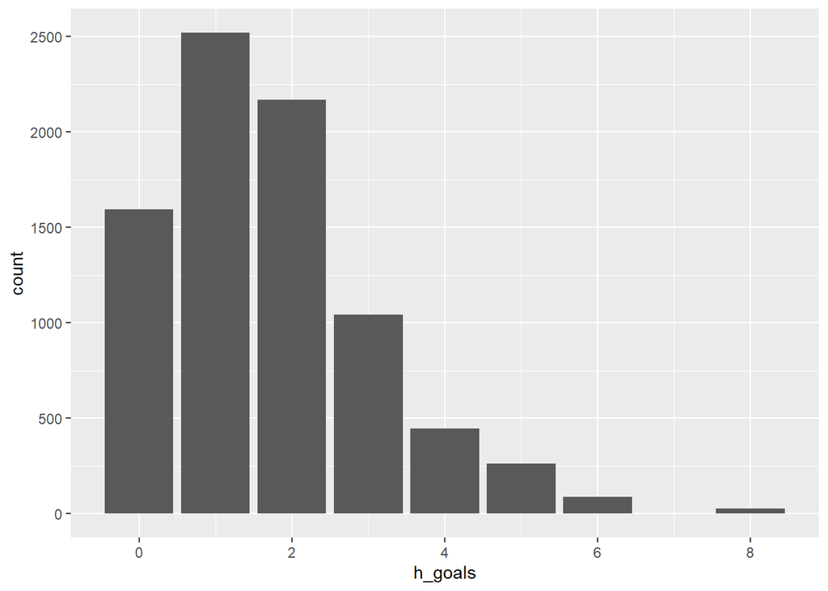

```r
library(ggplot2)

ggplot(bundesliga_shots_attributes, aes(x = h_goals)) +
  geom_bar()
```

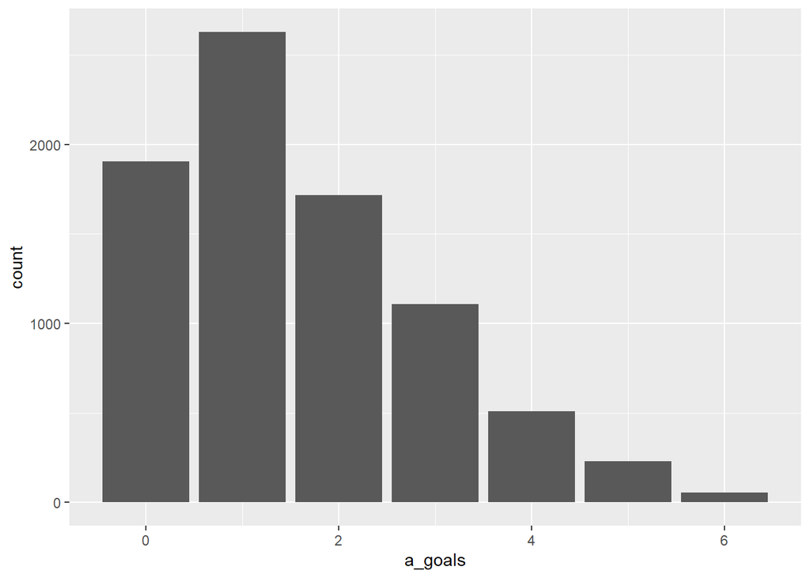

```r
ggplot(bundesliga_shots_attributes, aes(x = a_goals)) +
  geom_bar()
```

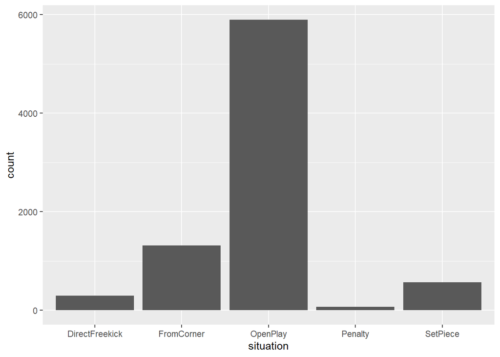

```r
ggplot(bundesliga_shots_attributes, aes(x = situation)) +
  geom_bar()
```

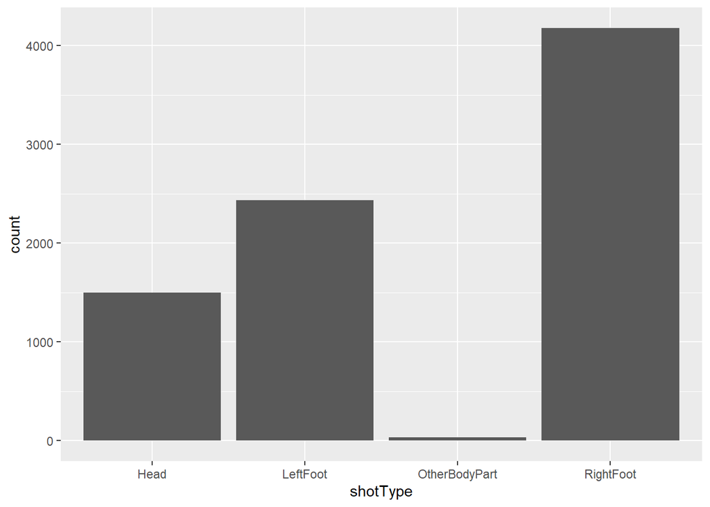

```r
ggplot(bundesliga_shots_attributes, aes(x = shotType)) +
  geom_bar()
```

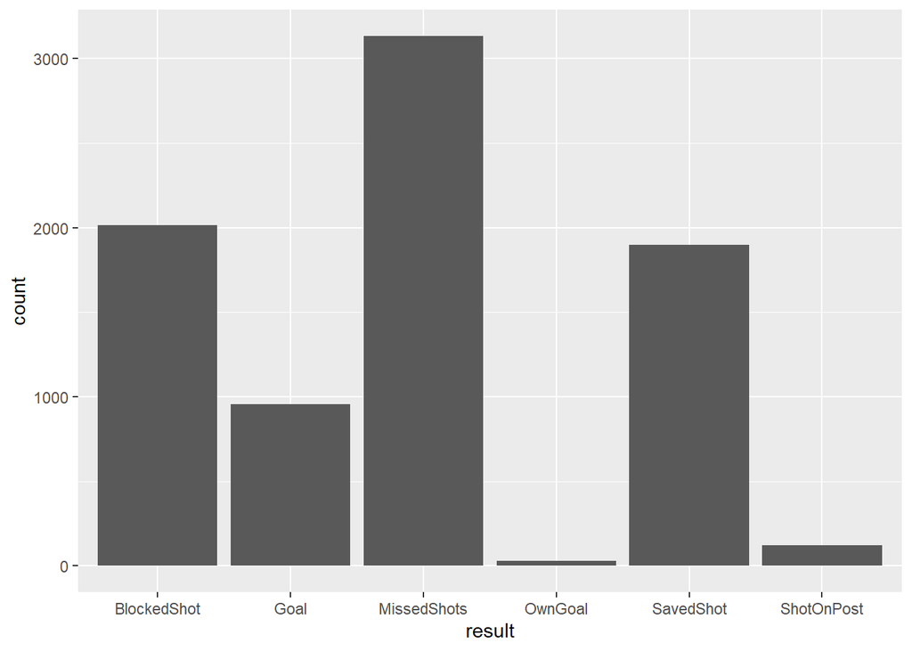

```r
ggplot(bundesliga_shots_attributes, aes(x = result)) +
  geom_bar()
```

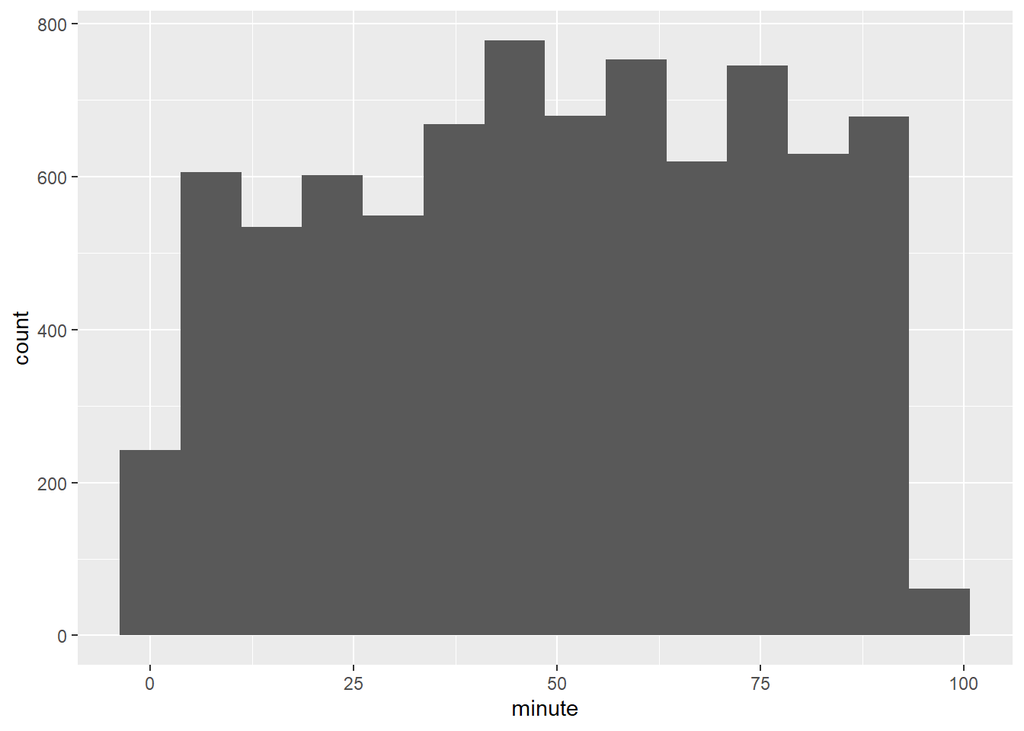

```r
ggplot(bundesliga_shots_attributes, aes(x = minute)) +
  geom_histogram(bins = nclass.Sturges(bundesliga_shots_attributes$minute))
```

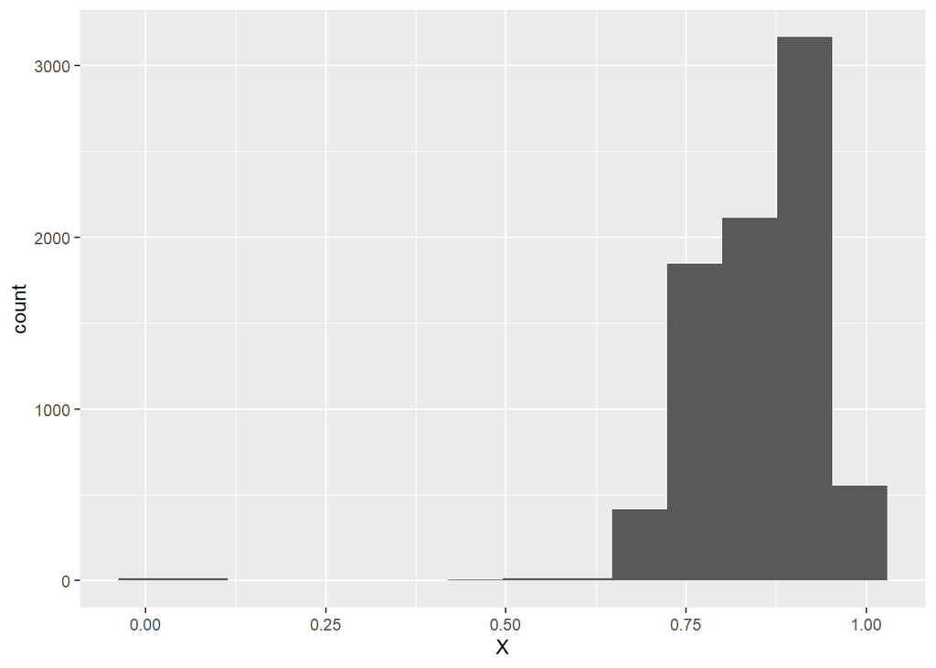

```r
ggplot(bundesliga_shots_attributes, aes(x = X)) +
  geom_histogram(bins = nclass.Sturges(bundesliga_shots_attributes$X))
```

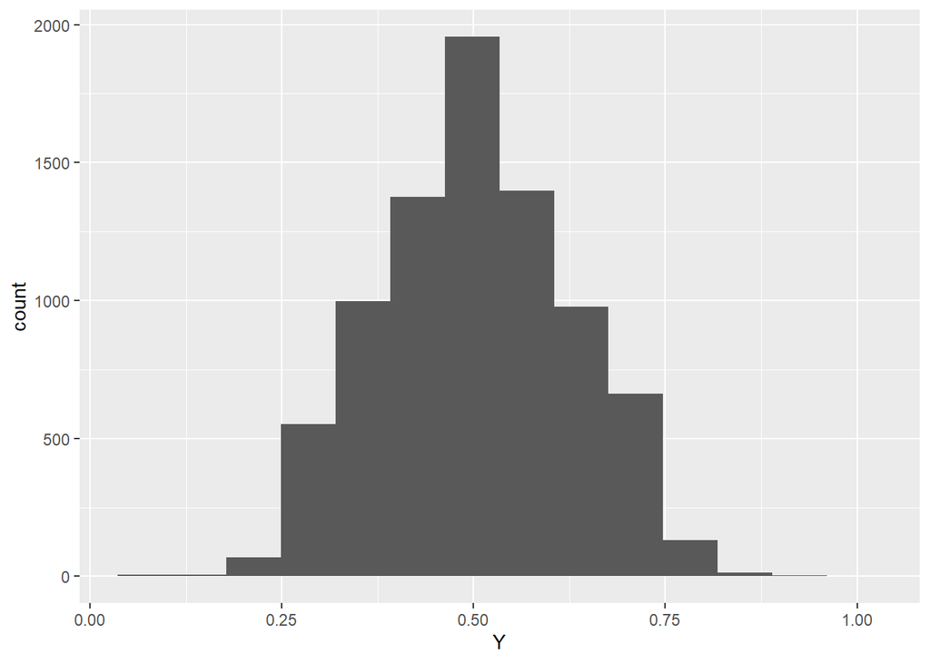

```r
ggplot(bundesliga_shots_attributes, aes(x = Y)) +
  geom_histogram(bins = nclass.Sturges(bundesliga_shots_attributes$Y))
```

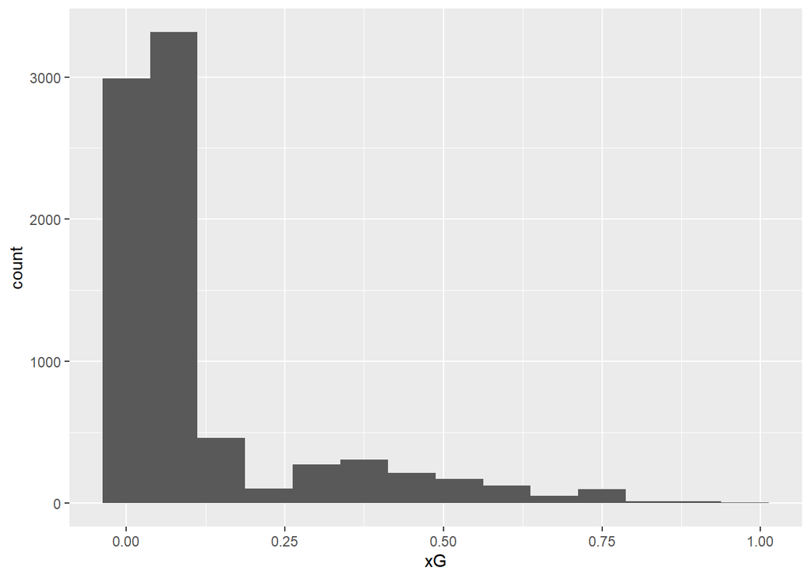

```r
ggplot(bundesliga_shots_attributes, aes(x = xG)) +
  geom_histogram(bins = nclass.Sturges(bundesliga_shots_attributes$xG))
```

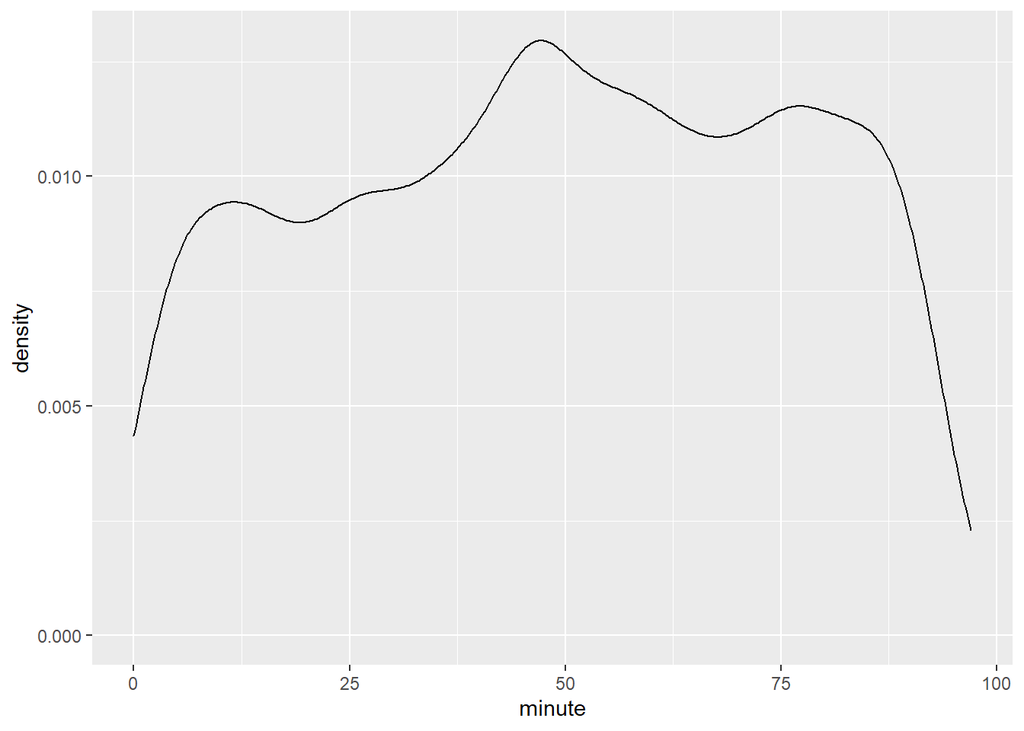

```r
ggplot(bundesliga_shots_attributes, aes(x = minute)) +
  geom_density()
```

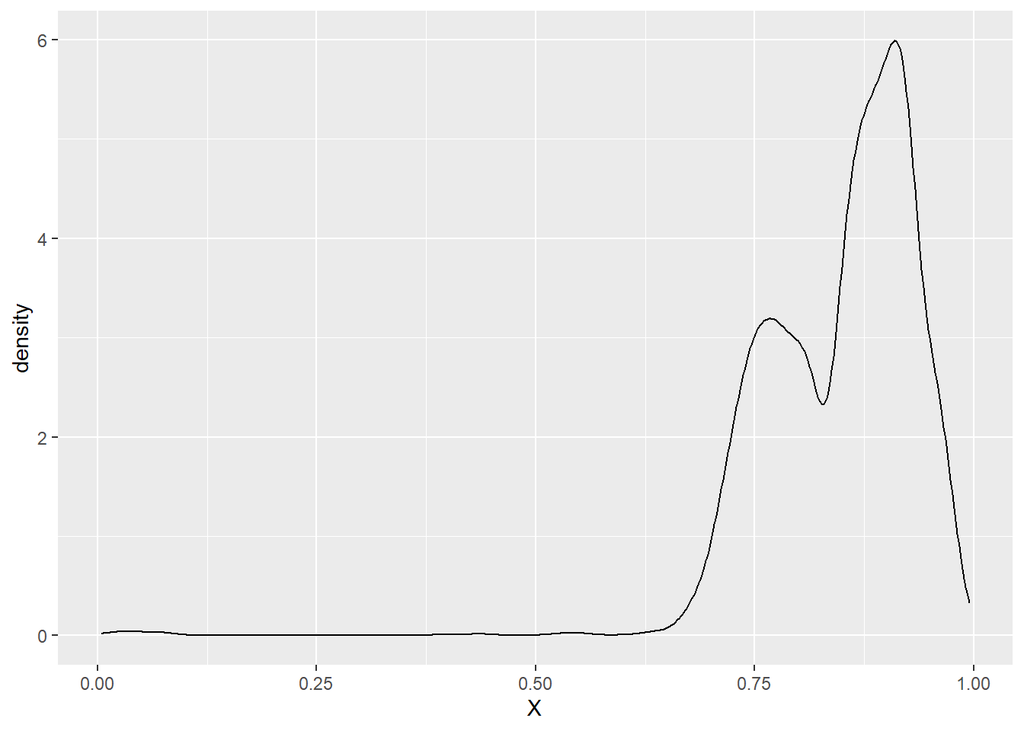

```r
ggplot(bundesliga_shots_attributes, aes(x = X)) +
  geom_density()
```

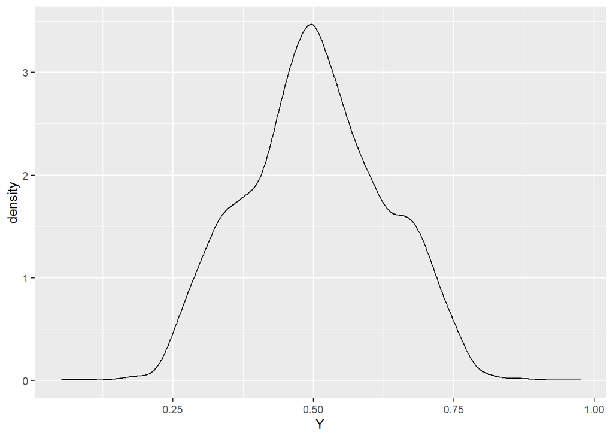

```r
ggplot(bundesliga_shots_attributes, aes(x = Y)) +
  geom_density()
```

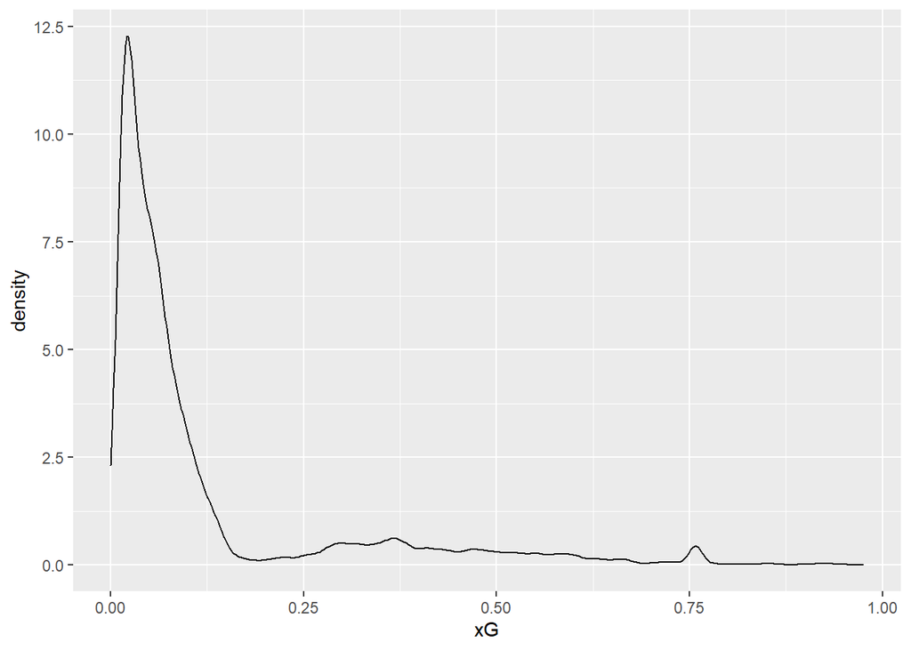

```r
ggplot(bundesliga_shots_attributes, aes(x = xG)) +
  geom_density()
```

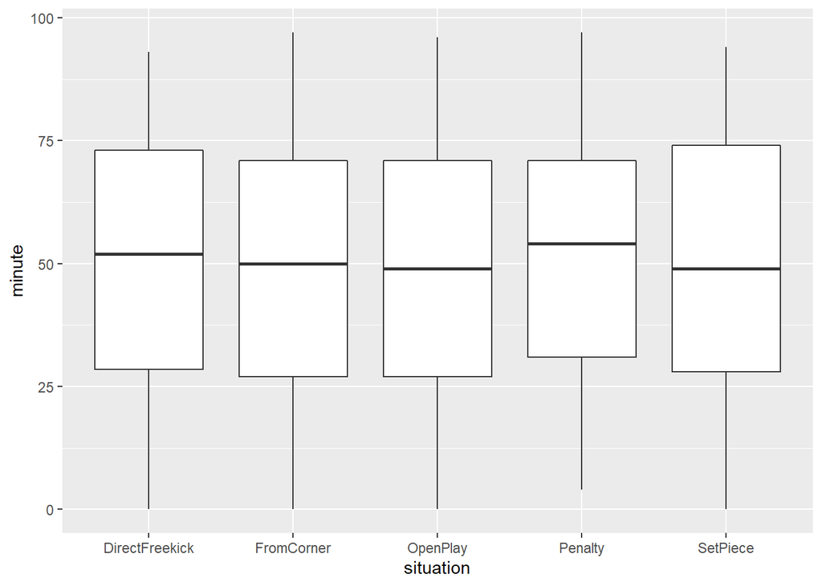

```r
ggplot(bundesliga_shots_attributes, (aes(x = situation, y = minute))) +
  geom_boxplot()
```

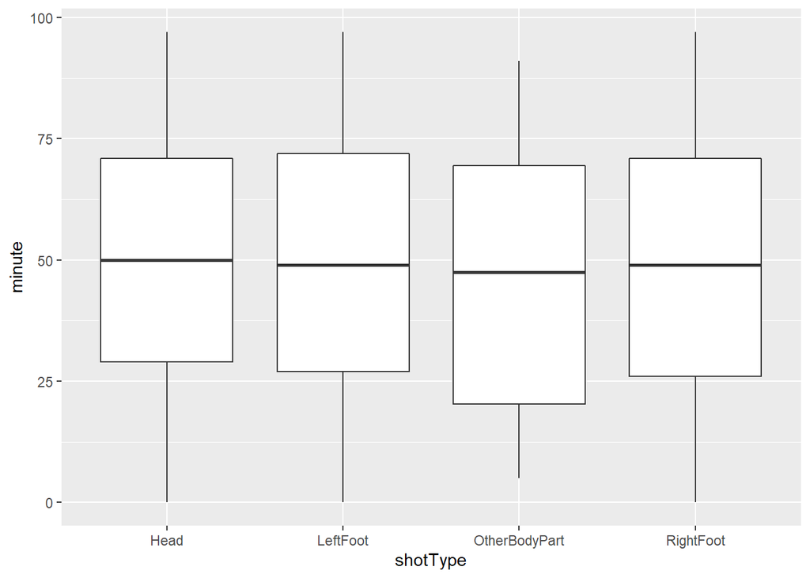

```r
ggplot(bundesliga_shots_attributes, (aes(x = shotType, y = minute))) +
  geom_boxplot()
```

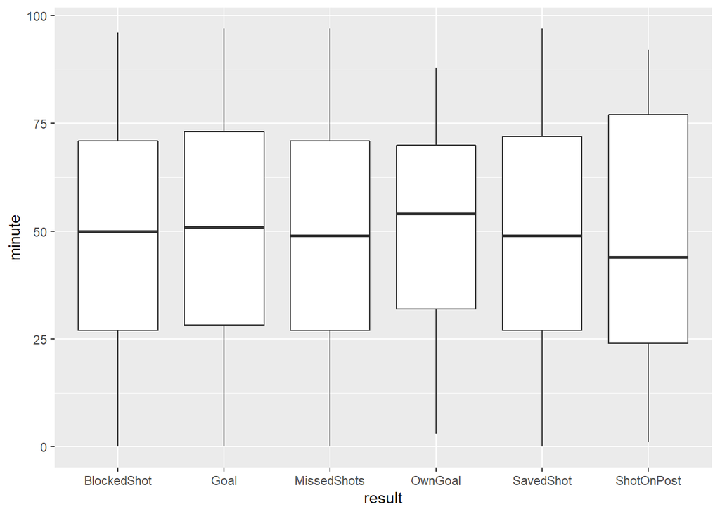

```r
ggplot(bundesliga_shots_attributes, (aes(x = result, y = minute))) +
  geom_boxplot()
```

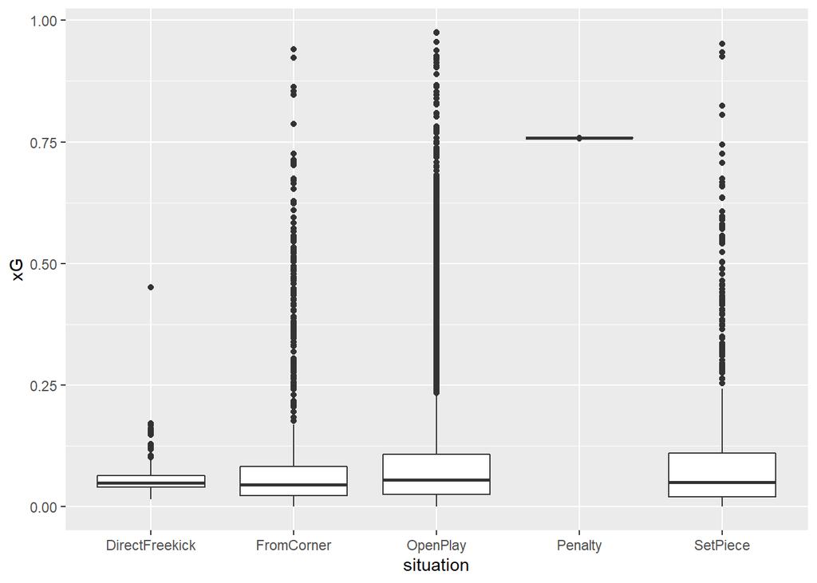

```r
ggplot(bundesliga_shots_attributes, (aes(x = situation, y = xG))) +
  geom_boxplot()
```

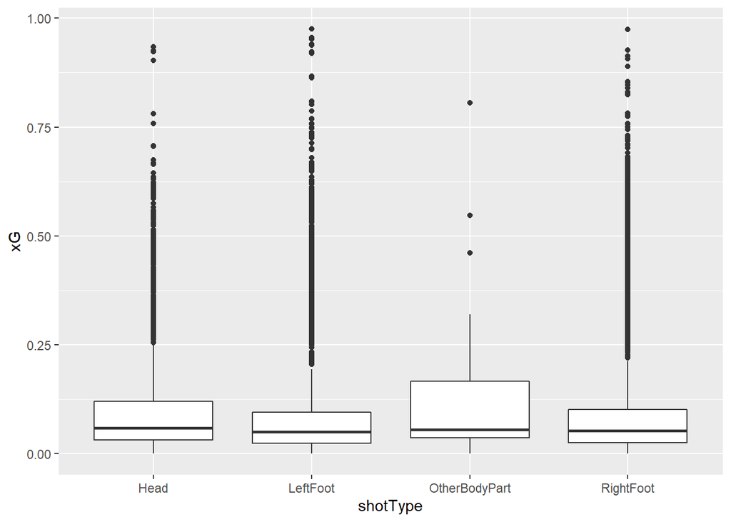

```r
ggplot(bundesliga_shots_attributes, (aes(x = shotType, y = xG))) +
  geom_boxplot()
```

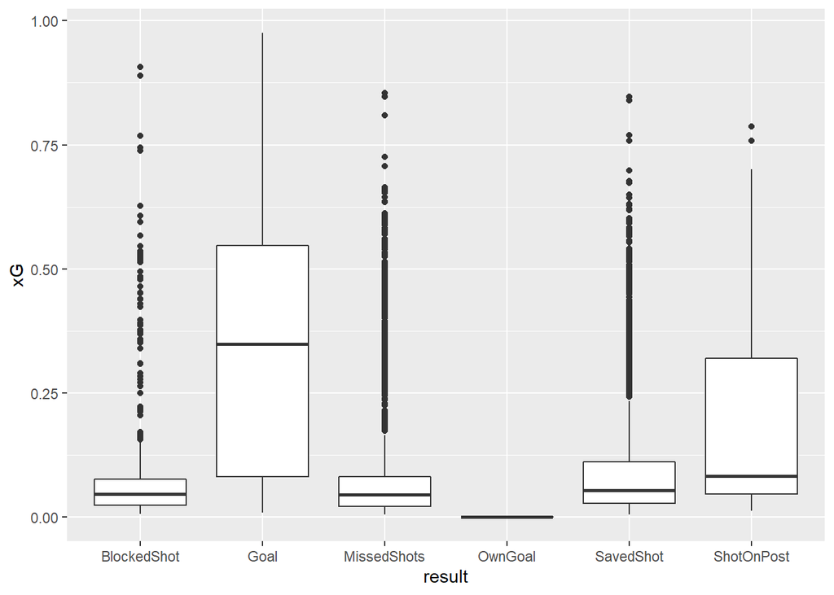

```r
ggplot(bundesliga_shots_attributes, (aes(x = result, y = xG))) +
  geom_boxplot()
```

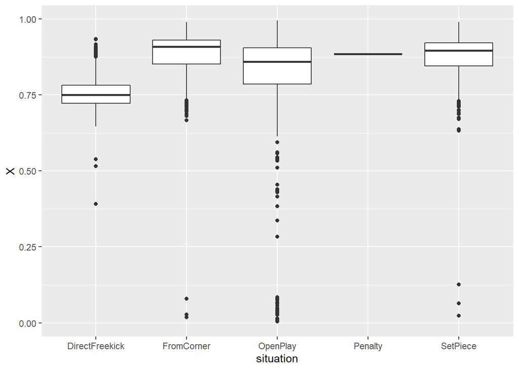

```r
ggplot(bundesliga_shots_attributes, (aes(x = situation, y = X))) +
  geom_boxplot()
```

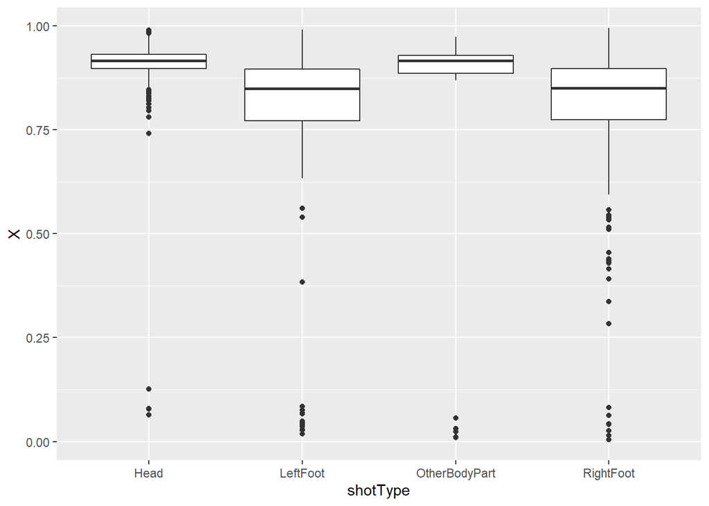

```r
ggplot(bundesliga_shots_attributes, (aes(x = shotType, y = X))) +
  geom_boxplot()
```

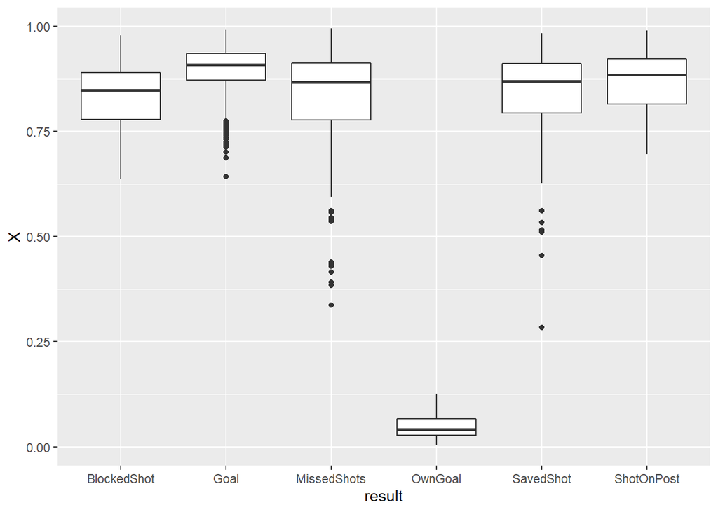

```r
ggplot(bundesliga_shots_attributes, (aes(x = result, y = X))) +
  geom_boxplot()
```

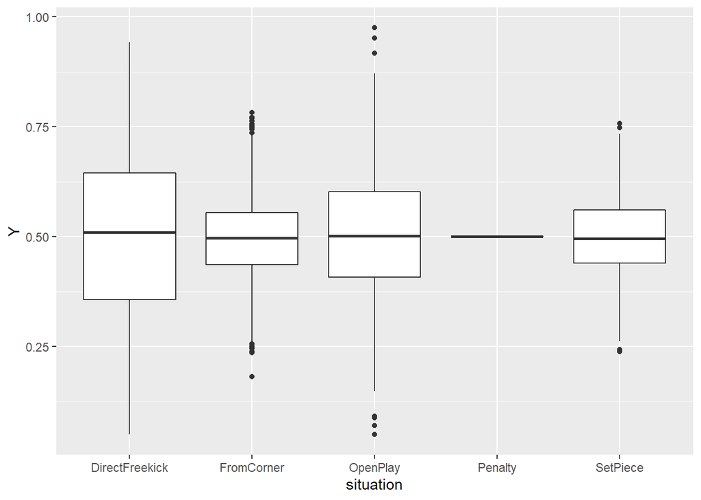

```r
ggplot(bundesliga_shots_attributes, (aes(x = situation, y = Y))) +
  geom_boxplot()
```

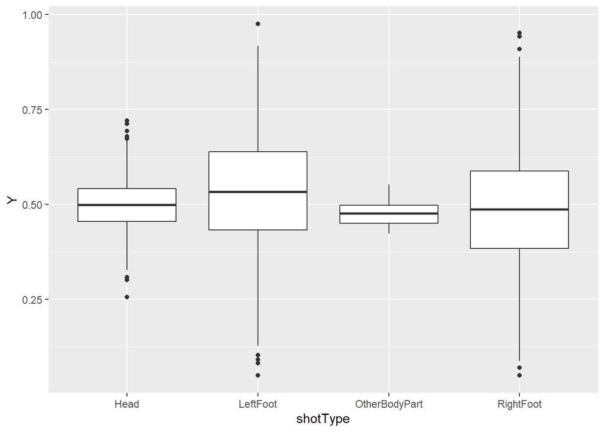

```r
ggplot(bundesliga_shots_attributes, (aes(x = shotType, y = Y))) +
  geom_boxplot()
```

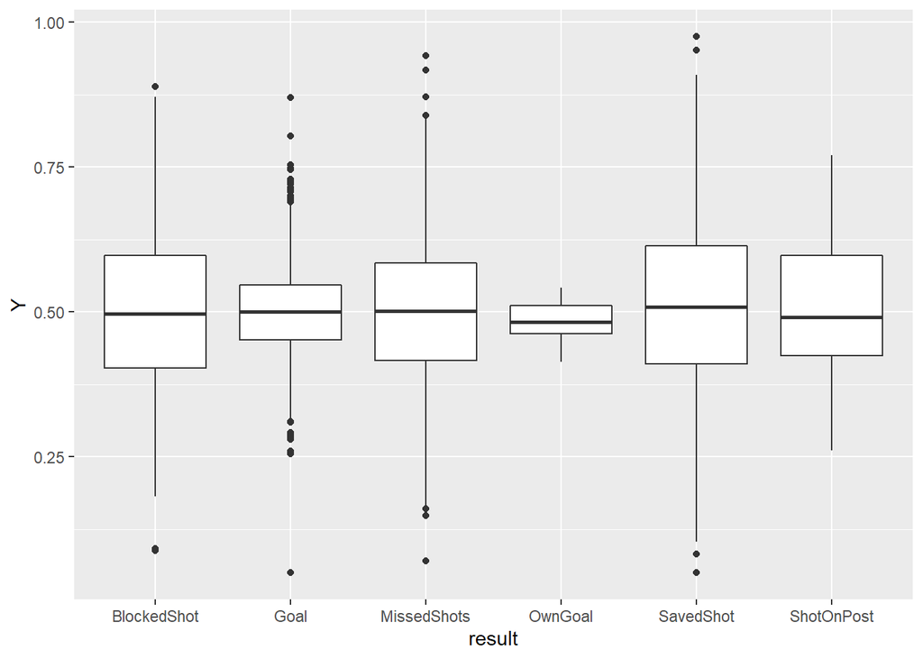

```r
ggplot(bundesliga_shots_attributes, (aes(x = result, y = Y))) +
  geom_boxplot()
```

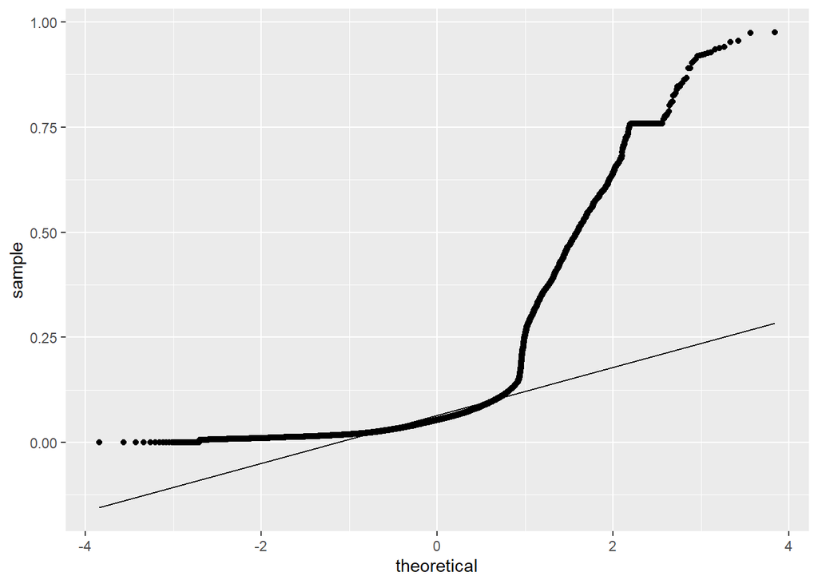

```r
ggplot(bundesliga_shots_attributes, aes(sample = xG)) +
  geom_qq() +
  geom_qq_line()
```

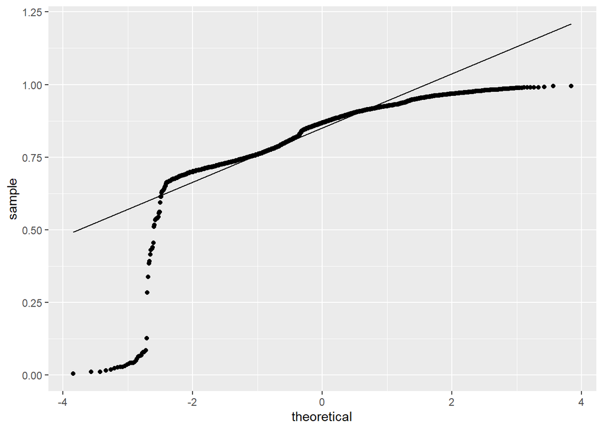

```r
ggplot(bundesliga_shots_attributes, aes(sample = X)) +
  geom_qq() +
  geom_qq_line()
```

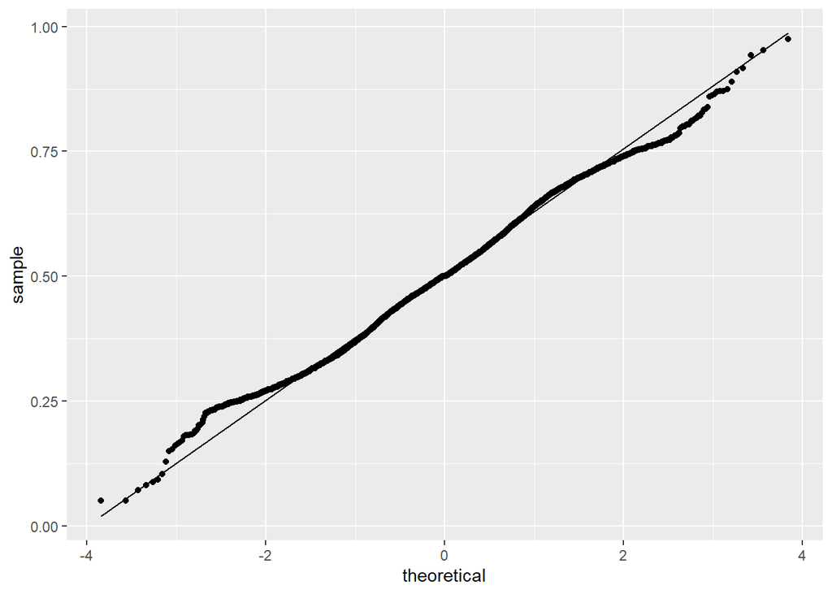

```r
ggplot(bundesliga_shots_attributes, aes(sample = Y)) +
  geom_qq() +
  geom_qq_line()
```

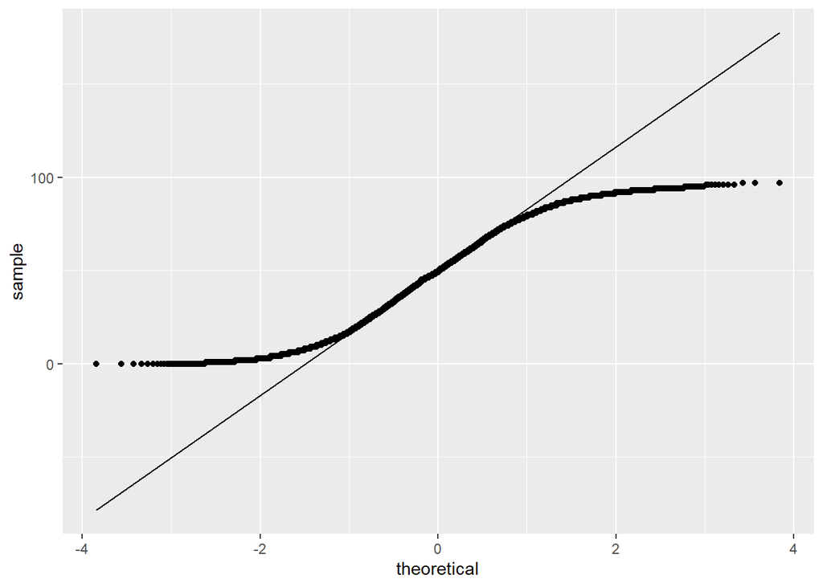

```r
ggplot(bundesliga_shots_attributes, aes(sample = minute)) +
  geom_qq() +
  geom_qq_line()
```